# R_finalproject_LiliKovari

## ## A hypothesis

According to Plot 2, in the USA, where most sightings are from, there may be a relationship between the length of the description and the duration of the phenomenon. We assume that the length of the description from the phenomenon reflects the saliency of the event, and is associated with more detailed memory formed from the perceived phenomenon, which may be rooted in the longer exposure to the event itself. Therefore, our hypothesis is that the duration of the event correlates with the length of the description of the event.

## ## Testing the hypothesis

```r
# descriptives

mean(usa$desc) # mean length of the description is ~82 characters
```

```
## [1] 82.40465
```

```r
sd_desc <- sd(usa$desc, na.rm = TRUE)
se_desc <- sd(usa$desc, na.rm = TRUE)/sqrt(sum(complete.cases(usa$desc)))
sd_desc # standard deviation is ~37,64
```

```
## [1] 37.63674
```

```r
se_desc # standard error of the mean is ~0,13
```

```
## [1] 0.129252
```

```r
mean(usa$duration_seconds) # mean duration time is ~10 864 seconds
```

```
## [1] 10864.02
```

```r
sd_duration <- sd(usa$duration_seconds, na.rm = TRUE)
se_duration <- sd(usa$duration_seconds, na.rm = TRUE)/sqrt(sum(complete.cases(usa$duration_seconds)))
sd_duration # standard deviation is ~73 218
```

```
## [1] 73218.62
```

```r
se_duration # standard error of the mean is ~251,45
```

```
## [1] 251.4471
```

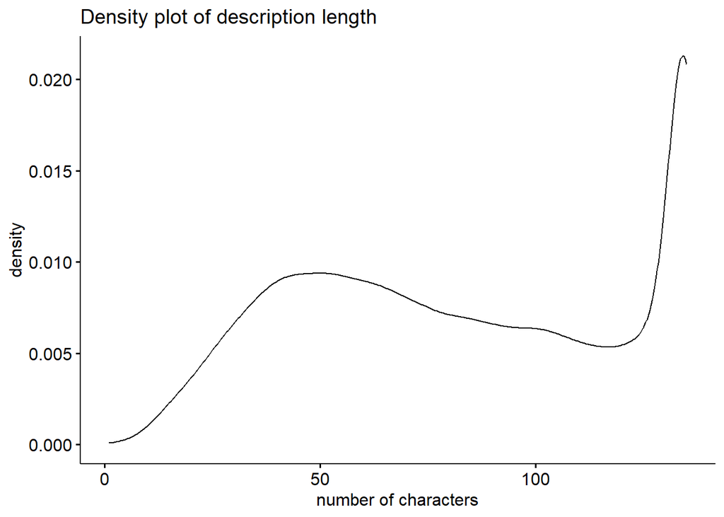

```r
# normality

descplot <- ggdensity(usa$desc, main = "Density plot of description length", xlab = "number of characters")
descplot # visual normality check for desc, indicating violation of normal distribution
```

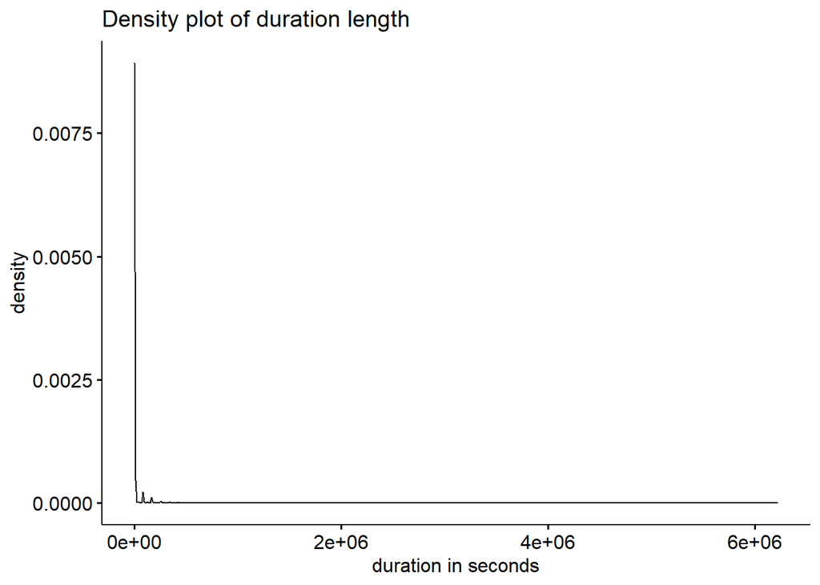

```r
durplot <- ggdensity(usa$duration_seconds, main = "Density plot of duration length", xlab = "duration in seconds")
durplot # visual normality check for dur, indicating violation of normal distribution
```

```r
nortest::lillie.test(usa$desc) # p value of Lilliefors (Kolmogorov-Smirnov) test is below .05
```

```
##
##  Lilliefors (Kolmogorov-Smirnov) normality test
##
## data:  usa$desc
## D = 0.096085, p-value < 2.2e-16
```

```r
nortest::lillie.test(usa$duration_seconds) # p value of Lilliefors (Kolmogorov-Smirnov) test is below .05
```

```
##
##  Lilliefors (Kolmogorov-Smirnov) normality test
##
## data:  usa$duration_seconds
## D = 0.47635, p-value < 2.2e-16
```

```r
# spearman correlation

des <- usa$desc
dur <- usa$duration_seconds

corr <-cor.test(des, dur,  method = "spearman")
corr # S = 9.8767e+13, p-value = 4.514e-16, rho = 0.02789404
```

```
##
##  Spearman's rank correlation rho
##
## data:  des and dur
## S = 9.8767e+13, p-value = 4.514e-16
## alternative hypothesis: true rho is not equal to 0
## sample estimates:
##        rho
## 0.02789404
```

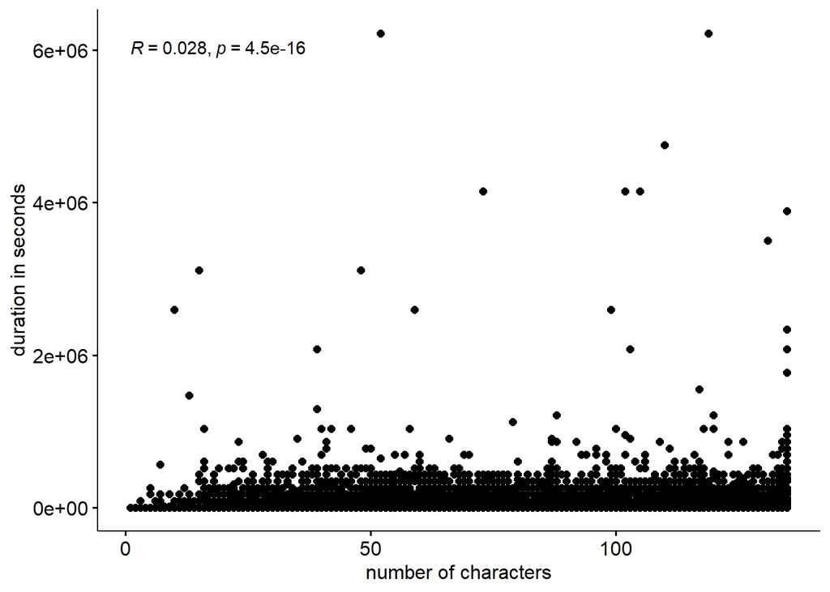

```r
ggscatter(usa, x = "desc", y = "duration_seconds",
          add = "reg.line", conf.int = TRUE,
          cor.coef = TRUE, cor.method = "spearman",
          xlab = "number of characters", ylab = "duration in seconds") # visualizing the correlation
```

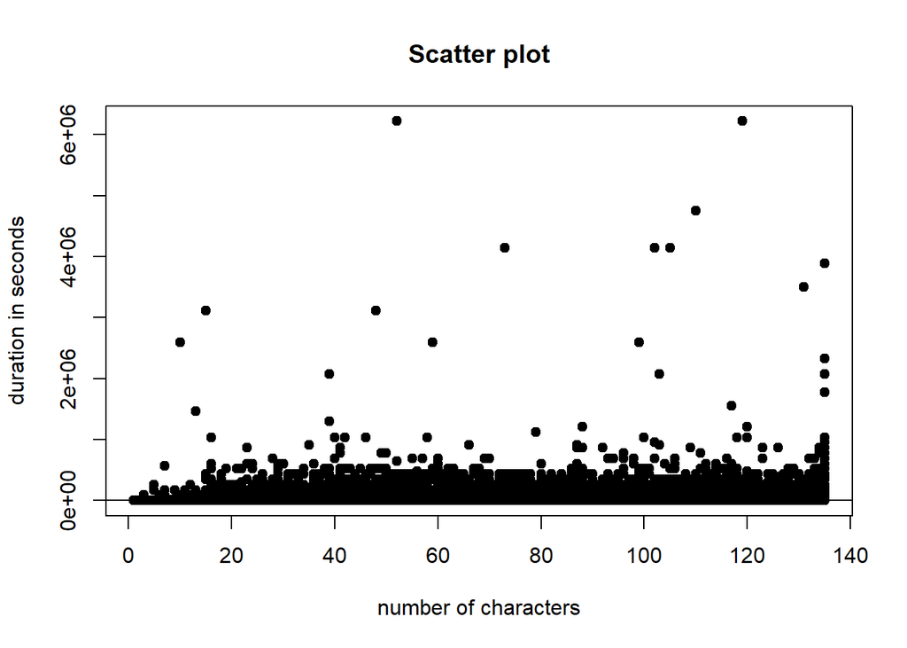

```r
plot(des,dur, main="Scatter plot", xlab="number of characters", ylab="duration in seconds", pch=19)
abline(lm(des~dur), col="black") # another visualization
```

## ## Results & discussion

This dataset includes several informations about UFO sightings from all around the world. Based on our exploratory data analysis, we can infer that most occurences were detected in the United States, therefore we limited the further analyses to that country. Based on the EDA, we hypothesised a relationship between the sightings’ descprition length and the sightings’ reported duration, consequently, we assumed a positive correlation between the number of characters of such descriptions and the duration of the sightings in seconds. Since the normality of the data was violated, we computed a Spearman’s correlation coefficient in order to determine the relationship between number of characters in descriptions and the sighting durations in seconds. Results indicate a significant yet positive weak relationship with rho = 0.028, p < .001. Thus, we can reject the null hypothesis but we can not conclude that there would be a strong relationship between the sightings’ descprition length and the sightings’ reported duration. Our results do not support our hypothesis, namely, we can not state that the longer exposure to such phenomenons would manifest in more detailed, longer verbal summaries of such events.